# Introduction to SBM and LBM. Practice

Sophie Donnet

19 juin 2019

- On commence par ouvrir le fichier *formation_blockmodels.r*.
- Je choisis mon répertoire de travail.

[figure not shown]

# Dataset : Vanuatu dataset. Sophie Caillon .

```r
# Relation between individuals
adjacency_individuals <- as.matrix(read.csv("ssna_adj_30n_all_ind_ssloop.csv", row.names=1))
adjacency_individuals_binary <- 1 * (adjacency_individuals > 0)
dim(adjacency_individuals)
```

```
## [1] 30 30
```

```r
isSymmetric(adjacency_individuals_binary)
```

```
## [1] FALSE
```

```r
diag(adjacency_individuals_binary)
```

```
## IND_001 IND_005 IND_012 IND_017 IND_019 IND_026 IND_029 IND_032 IND_045
##       0       0       0       0       0       0       0       0       0
## IND_046 IND_049 IND_055 IND_058 IND_081 IND_088 IND_092 IND_099 IND_100
##       0       0       0       0       0       0       0       0       0
## IND_101 IND_102 IND_103 IND_115 IND_130 IND_143 IND_152 IND_158 IND_159
##       0       0       0       0       0       0       0       0       0
## IND_173 IND_183 IND_184
##       0       0       0
```

```r
# Inventory of species

inventory_species <- read.csv("inventory_species.csv", row.names=1)
incidence_species <- as.matrix(inventory_species)
incidence_species_binary <- 1 * (incidence_species > 0)
dim(incidence_species)
```

```
## [1] 30 37
```

- $30$ individuals, $37$ species
- “adjacency_individuals” : weighted individuals interactions (number of seed exchanges)
- “adjacency_individuals_binary” : binary individuals interactions (seed exchanges yes (1) or no (0))
- “incidence_species” : weighted individuals - species interactions
- “incidence_species_binary” : binary individuals - species interactions

# Useful packages

- R-package blockmodels to infer Stochastic Block Model [SBM] and Latent Block model [LBM] on ecological networks
- We will also need the ggplot2, igraph and alluvial packages.

```r
library(blockmodels)
```

```r
library(igraph)
library(alluvial)
library(ggplot2)
```

- For this class, we wrote additional ad-hoc functions. They are in the following file:

```r
source('function_for_blockmodels.R')
```

# Stochastic Block Model for Binary Network

## Dataset : binary seed circulation network

We consider that two individuals are in interaction if they exchange at least one time.

- Plot of the adjacency matrix:

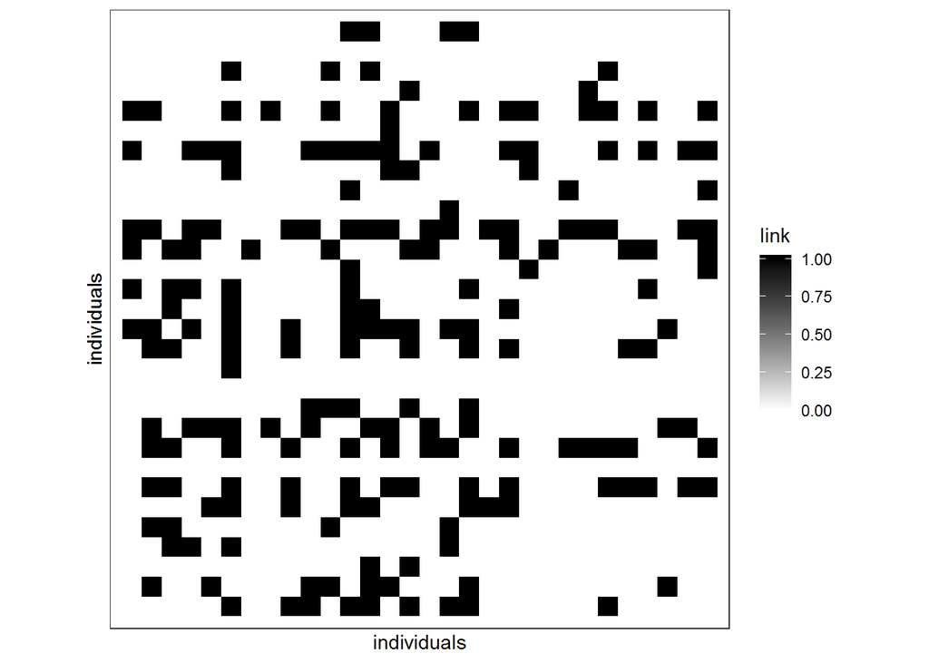

```r
plotMatrix(Mat = adjacency_individuals_binary,rowFG = 'individuals', colFG  = 'individuals')
```

## Model and inference

$$\begin{align*}
(Z_i) \text{ i.i.d.} \qquad & Z_i \sim \mathcal{M}(1, \pi) \\
(Y_{ij}) \text{ indep.} \mid (Z_i) \qquad & (Y_{ij} \mid Z_i=k, Z_j = \ell) \sim \mathcal{B}(\alpha_{k\ell})
\end{align*}$$

- Blockmodel : object programming
- First we define the object

```r
sbm.bern <- BM_bernoulli("SBM",adjacency_individuals_binary)
```

- Then we apply the inference method

```r
sbm.bern$estimate()
```

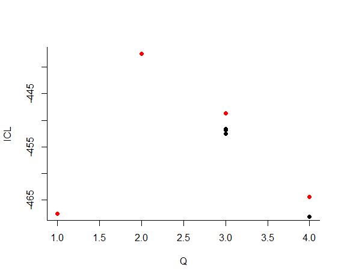

- The various points correspond to several runs of the estimation (resulting into a model selection criteria value) for a given number of clusters (denoted $Q$ here).
- We select the best number of clusters (with respect to the ICL criteria).

```r
bestmodel = which.max(sbm.bern$ICL)
bestmodel
```

```
## [1] 2
```

- We can now extract the parameters of interest, namely ($\alpha$, $\pi$) and the nodes (here individuals) clustering $Z$

```r
paramEstimSBM.bern <- extractParamBM(sbm.bern,bestmodel)
paramEstimSBM.bern$pi
```

```
## [1] 0.4147232 0.5852768
```

```r
paramEstimSBM.bern$alpha
```

```
##            [,1]       [,2]
## [1,] 0.37006753 0.43784224
## [2,] 0.09161835 0.09524843
```

```r
paramEstimSBM.bern$Z
```

```
##  [1] 2 2 2 2 1 2 1 2 2 2 1 1 2 1 2 1 1 2 2 2 1 1 2 1 1 2 2 2 1 1
```

- One can plot the reorganized matrix according to the clustering.

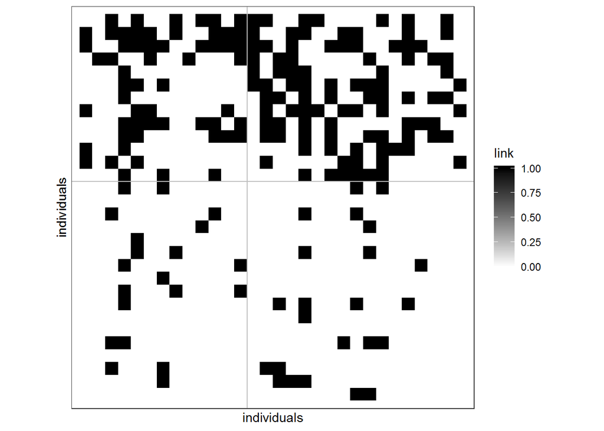

```r
plotMatrix(adjacency_individuals_binary,'individuals','individuals', fileNameSave = NULL, clustering = list(row = paramEstimSBM.bern$Z))
```

- Finally one can plot the macroview of the network.

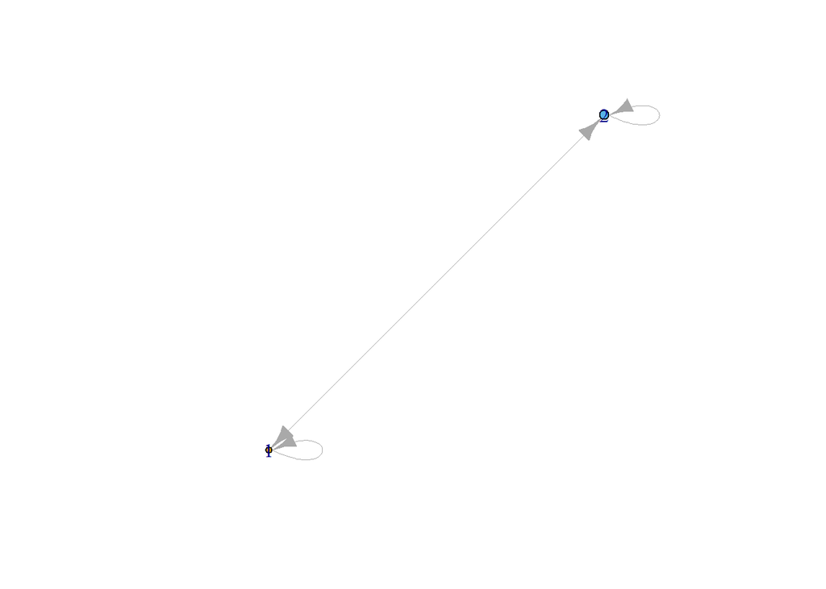

```r
G <- graph_from_adjacency_matrix(paramEstimSBM.bern$alpha, mode = c("directed"), weighted = TRUE, diag = TRUE)
plot.igraph(G,vertex.size = paramEstimSBM.bern$pi*10,edge.width= abs(E(G)$weight)*2,vertex.color = 1:paramEstimSBM.bern$Q, layout = layout_nicely)
```

- The composition of the clusters/blocks are given by:

```r
lapply(1:paramEstimSBM.bern$Q,function(q){rownames(adjacency_individuals_binary)[paramEstimSBM.bern$Z == q]})
```

```
## [[1]]
##  [1] "IND_019" "IND_029" "IND_049" "IND_055" "IND_081" "IND_092" "IND_099"
##  [8] "IND_103" "IND_115" "IND_143" "IND_152" "IND_183" "IND_184"
##
## [[2]]
##  [1] "IND_001" "IND_005" "IND_012" "IND_017" "IND_026" "IND_032" "IND_045"
##  [8] "IND_046" "IND_058" "IND_088" "IND_100" "IND_101" "IND_102" "IND_130"
## [15] "IND_158" "IND_159" "IND_173"
```

# SBM for Counting Network

## Dataset : weighted individuals interactions

In the weighted individuals interactions network, each edge is valued with the number of exchanges.

- Plot of the adjacency matrix:

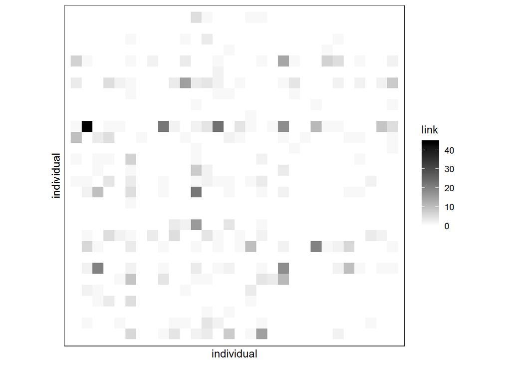

```r
plotMatrix(Mat = adjacency_individuals,rowFG = 'individual', colFG  = 'individual')
```

## Model and inference

We consider the SBM Poisson model.

$$\begin{align*}
(Z_i) \text{ i.i.d.} \qquad & Z_i \sim \mathcal{M}(1, \pi) \\
(Y_{ij}) \text{ indep.} \mid (Z_i) \qquad & (Y_{ij} \mid Z_i=k, Z_j = \ell) \sim \mathcal{P}(\exp(\alpha_{kl})) = \mathcal{P}(\lambda_{kl})
\end{align*}$$

```r
sbm.poiss <- BM_poisson("SBM",adjacency_individuals)
```

- Then we apply the inference method

```r
sbm.poiss$estimate()
save(sbm.poiss,file = 'res_sbm_poiss.Rdata')
```

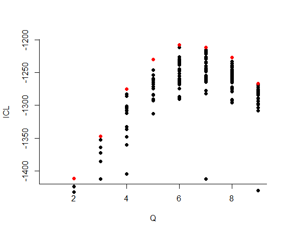

- We select the best number of clusters (with respect to the ICL criteria)

```r
Q = which.max(sbm.poiss$ICL)
Q
```

```
## [1] 6
```

- We can now extract the parameters of interest, namely ($\lambda$, $\pi$) and the clustering of the nodes.

```r
paramEstimSBM.pois <- extractParamBM(sbm.poiss,Q)
paramEstimSBM.pois$pi
```

```
## [1] 0.03596491 0.10131579 0.19934211 0.06864035 0.16666667 0.42807018
```

```r
paramEstimSBM.pois$lambda
```

```
##           [,1]        [,2]       [,3]      [,4]        [,5]      [,6]
## [1,] 2.9108186 0.454454199 1.90996957 9.1123315 19.68141007 0.7255157
## [2,] 5.4795329 0.390512445 2.42564336 3.3871892  2.22454934 1.0219545
## [3,] 0.1325658 0.203152428 0.29096426 4.7907928  0.68801349 1.8622773
## [4,] 1.4204663 0.341607963 0.19190264 7.3565286  0.07166707 1.1322278
## [5,] 0.2119632 0.071908883 0.04408649 0.2399074  0.22314785 0.3148203
## [6,] 0.1595467 0.005982793 0.14372372 0.6433395  0.08672191 0.1710941
```

```r
paramEstimSBM.pois$Z
```

```
##  [1] 6 5 6 6 2 6 2 6 5 6 1 4 6 5 6 3 3 6 6 4 3 2 5 3 3 6 6 6 5 3
```

- One can plot the reorganized matrix according to the clustering.

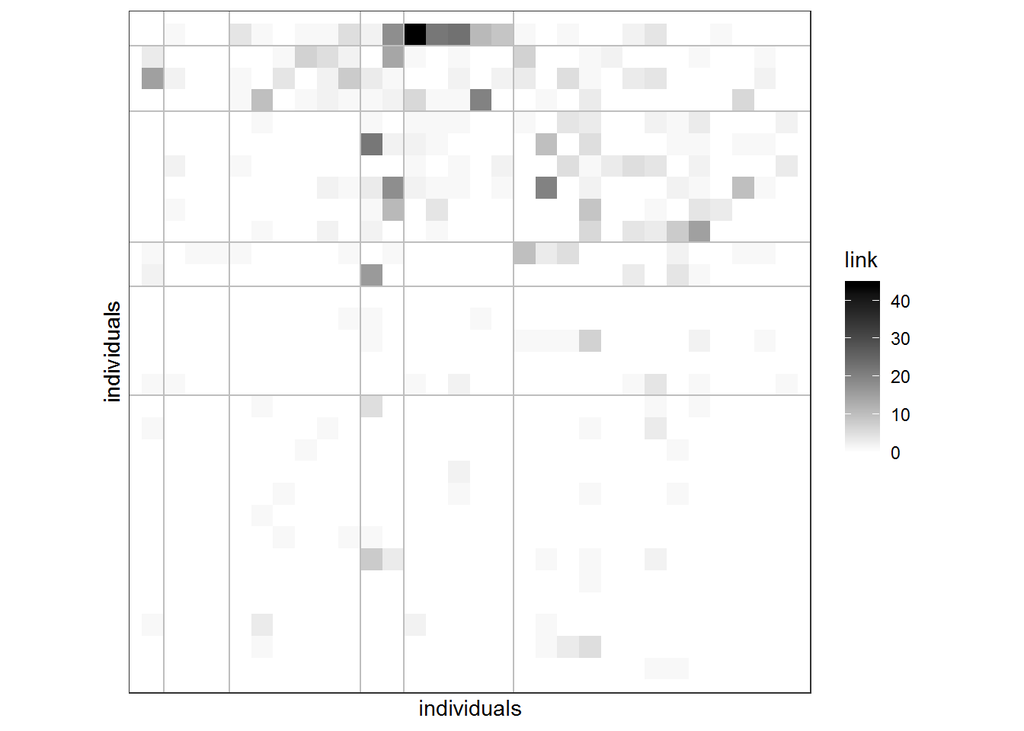

```r
plotMatrix(adjacency_individuals,'individuals','individuals', fileNameSave = NULL, clustering = list(row = paramEstimSBM.pois$Z))
```

- One can plot the macroview of the network.

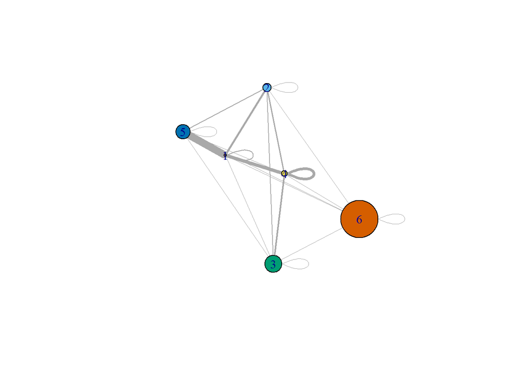

```r
G <- graph_from_adjacency_matrix(paramEstimSBM.pois$lambda, mode = c("undirected"), weighted = TRUE, diag = TRUE)
plot.igraph(G,vertex.size=paramEstimSBM.pois$pi*100,edge.width=abs(E(G)$weight)*0.5,vertex.color=1:paramEstimSBM.pois$Q, layout=layout_nicely)
```

- The composition of the clusters/blocks are given by :

```r
lapply(1:paramEstimSBM.pois$Q,function(q){rownames(adjacency_individuals_binary)[paramEstimSBM.pois$Z == q]})
```

```
## [[1]]
## [1] "IND_049"
##
## [[2]]
## [1] "IND_019" "IND_029" "IND_115"
##
## [[3]]
## [1] "IND_092" "IND_099" "IND_103" "IND_143" "IND_152" "IND_184"
##
## [[4]]
## [1] "IND_055" "IND_102"
##
## [[5]]
## [1] "IND_005" "IND_045" "IND_081" "IND_130" "IND_183"
##
## [[6]]
##  [1] "IND_001" "IND_012" "IND_017" "IND_026" "IND_032" "IND_046" "IND_058"
##  [8] "IND_088" "IND_100" "IND_101" "IND_158" "IND_159" "IND_173"
```

We are interested in comparing the two cluterings. To do so we use the alluvial flow plots.

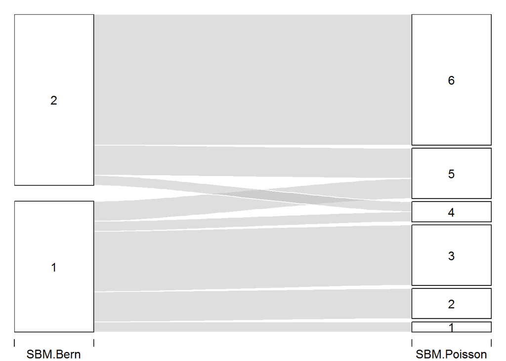

```r
A <- as.data.frame(table(paramEstimSBM.bern$Z,paramEstimSBM.pois$Z))
colnames(A)=c('SBM Bern',"SBM Poisson","Freq")
w   <- which(A$Freq!=0)
A <- A[w,]
alluvial(A[,c(1,2)],freq=A$Freq)
```

# Latent Block model

## Dataset : individuals/species interactions

- Plot of the incidence matrix

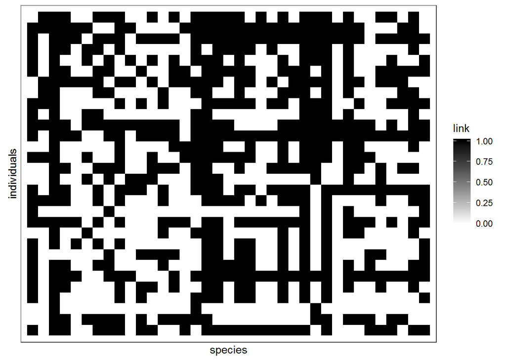

```r
plotMatrix(Mat = incidence_species_binary,rowFG = 'individuals', colFG  = 'species')
```

We can know try to get a clustering of individuals and species conjointly.

## Model and inference

$$\begin{align*}
(Z^R_i) \text{ i.i.d.} \qquad & Z^R_i \sim \mathcal{M}(1, \pi^R) \\
(Z^C_i) \text{ i.i.d.} \qquad & Z^C_i \sim \mathcal{M}(1, \pi^C) \\
(Y_{ij}) \text{ indep.} \mid (Z^R_i, Z^C_j) \qquad & (Y_{ij} \mid Z^R_i=k, Z^C_j = \ell) \sim \mathcal{B}(\alpha_{k\ell})
\end{align*}$$

```r
lbm_bern <- BM_bernoulli("LBM",incidence_species_binary)
lbm_bern$estimate()
```

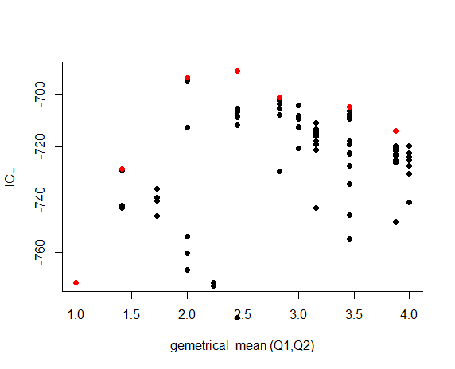

- We select the best number of clusters (with respect to the ICL criteria)

```r
BestModel = which.max(lbm_bern$ICL)
BestModel
```

```
## [1] 5
```

```r
paramEstimLBM_bern <- extractParamBM(lbm_bern,BestModel )
paramEstimLBM_bern$Q
```

```
## QRow QCol
##    3    2
```

- We can extract the parameters of interest, namely ($\alpha$, $\pi$) and the clustering of the nodes.

```r
paramEstimLBM_bern$piRow
```

```
## [1] 0.34363456 0.58557860 0.07078684
```

```r
paramEstimLBM_bern$piCol
```

```
## [1] 0.3379625 0.6620375
```

```r
paramEstimLBM_bern$alpha
```

```
##           [,1]       [,2]
## [1,] 0.9176489 0.64553932
## [2,] 0.7493397 0.29449658
## [3,] 0.2720344 0.07939952
```

```r
paramEstimLBM_bern$ZRow
```

```
##  [1] 2 1 1 2 2 1 1 2 2 2 1 1 2 2 2 2 1 2 3 1 2 2 2 2 1 2 2 3 2 1
```

```r
paramEstimLBM_bern$ZCol
```

```
##  [1] 1 2 1 2 2 2 2 2 1 2 2 2 2 2 2 1 1 1 2 1 2 2 2 1 2 1 2 1 2 1 2 2 2 2 2
## [36] 1 2
```

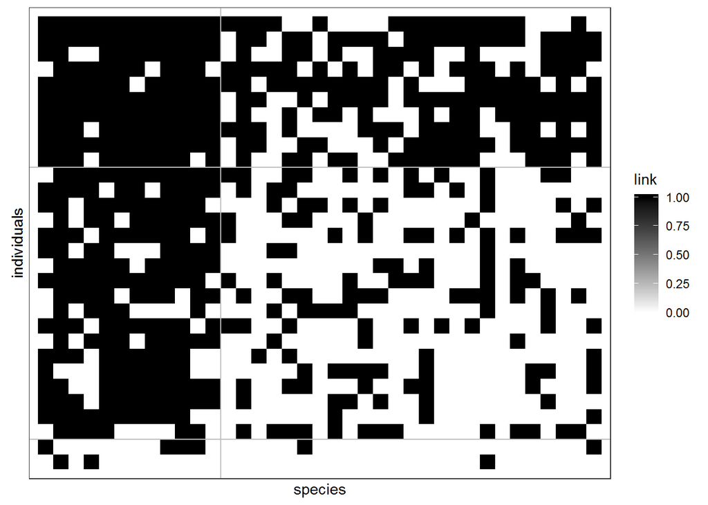

```r
plotMatrix(incidence_species_binary,'individuals','species', fileNameSave = NULL, clustering = list(row = paramEstimLBM_bern$ZRow,col = paramEstimLBM_bern$ZCol))
```

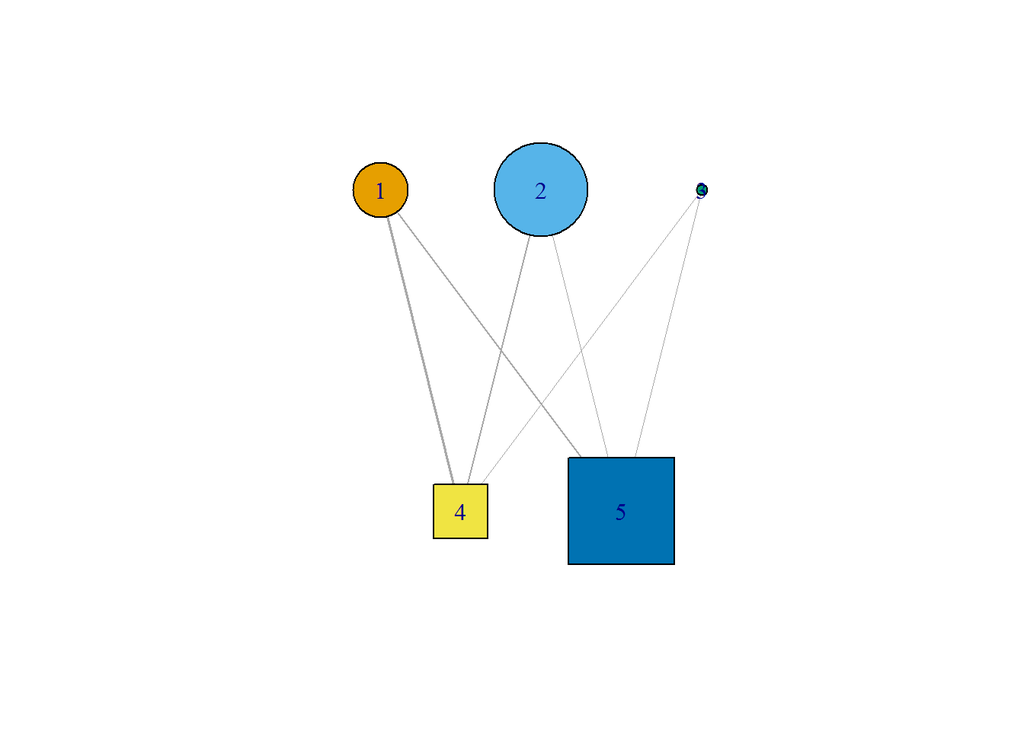

```r
G <- graph_from_incidence_matrix(paramEstimLBM_bern$alpha, weighted = TRUE)
plot(G,vertex.size=c(paramEstimLBM_bern$piRow*100, paramEstimLBM_bern$piCol*100), vertex.shape=c("circle", "square")[V(G)$type +1], edge.width=abs(E(G)$weight*2),vertex.color=1:sum(paramEstimLBM_bern$Q), layout=layout.bipartite)
```

- Exercise : give the name list of the various clusters.

# Latent Block model for weighted networks

## Dataset : individuals-species interactions

- Plot of the incidence matrix

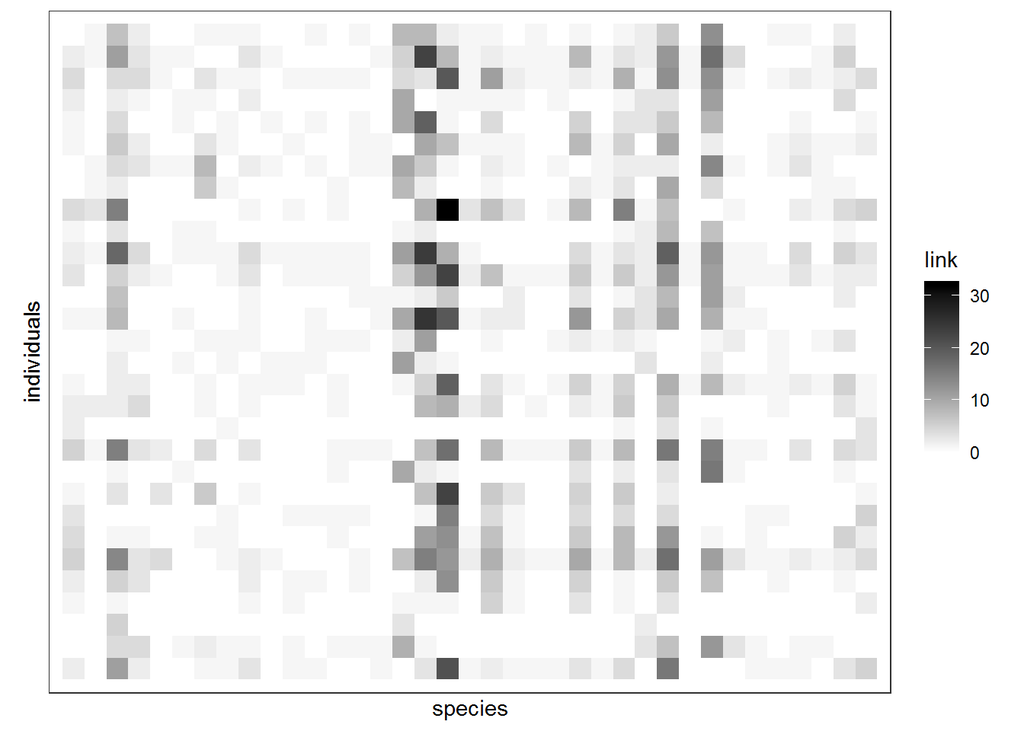

```r
plotMatrix(Mat = incidence_species,rowFG = 'individuals', colFG  = 'species')
```

We can now try to get a clustering of individuals and species conjointly.

## Model and inference

```r
lbm_pois <- BM_poisson("LBM",incidence_species)
lbm_pois$estimate()
```

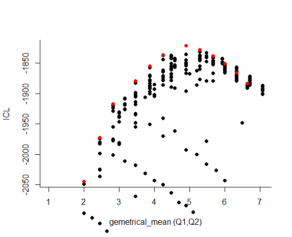

- We select the best number of clusters (with respect to the ICL criteria)

```r
BestModel = which.max(lbm_pois$ICL)
BestModel
```

```
## [1] 10
```

```r
paramEstimLBM_pois <- extractParamBM(lbm_pois,BestModel )
paramEstimLBM_pois$Q
```

```
## QRow QCol
##    4    6
```

- We can extract the parameters of interest, namely ($\alpha$, $\pi$) and the clustering of the nodes.

```r
paramEstimLBM_pois$piRow
```

```
## [1] 0.2335541 0.2993377 0.2667211 0.2003871
```

```r
paramEstimLBM_pois$piCol
```

```
## [1] 0.02926724 0.08245411 0.05586067 0.08245411 0.25690193 0.49306193
```

```r
paramEstimLBM_pois$alpha
```

```
##            [,1]      [,2]      [,3]        [,4]        [,5]       [,6]
## [1,]  2.6655276 2.5693747 2.1919679  1.79476576  0.76516799 -0.3762415
## [2,]  2.7377420 1.8356618 0.1385660  1.62234033  0.34798885 -0.9214536
## [3,]  0.4614786 1.5572329 2.2238770  0.42095437  0.03965336 -1.1416847
## [4,] -0.7088698 0.8549817 0.8654145 -0.07844738 -0.68142469 -1.7884171
```

```r
paramEstimLBM_pois$ZRow
```

```
##  [1] 3 1 1 3 3 2 3 3 2 4 1 1 3 1 4 4 2 2 4 1 3 2 2 2 1 2 4 4 3 2
```

```r
paramEstimLBM_pois$ZCol
```

```
##  [1] 5 6 2 5 6 6 5 6 5 6 6 6 6 6 6 3 2 1 6 4 5 6 6 4 6 4 5 2 6 3 5 6 6 5 6
## [36] 5 5
```

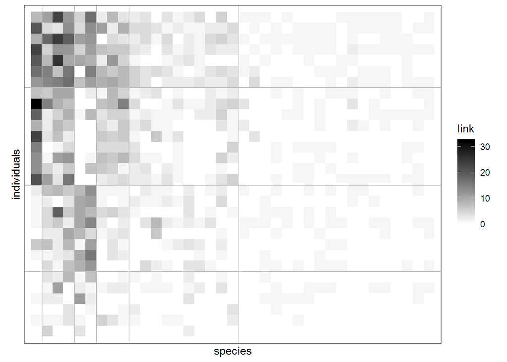

```r
plotMatrix(incidence_species,'individuals','species', fileNameSave = NULL, clustering = list(row = paramEstimLBM_pois$ZRow,col = paramEstimLBM_pois$ZCol))
```

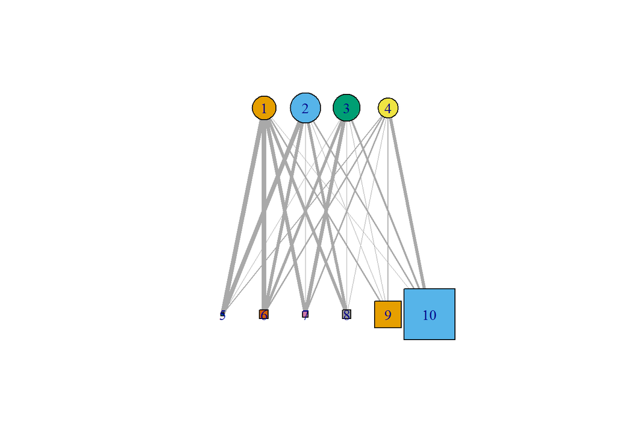

```r
G <- graph_from_incidence_matrix(paramEstimLBM_pois$alpha, weighted = TRUE)
plot(G,vertex.size = c(paramEstimLBM_pois$piRow*100, paramEstimLBM_pois$piCol * 100), vertex.shape = c("circle", "square")[V(G)$type + 1], edge.width=abs(E(G)$weight * 2),vertex.color = 1:sum(paramEstimLBM_pois$Q), layout = layout.bipartite)
```